# Twitter Scraping

## @realDonaldTrump

- Presidential Announcement: June 16, 2015
- Presumptive Nominee: May 4, 2016

[figure not shown]

## Initial Questions

- How do people feel about Trump?
- Has sentiment changed over time?
- What are the most frequent words tweeted to him?
- Will this give us an idea of whether he'll win?

## Data

- Tweets from June 1, 2015 to May 20, 2016
- 5889 tweets
- Looked at text, date, location, #, @, retweets, likes

[figure not shown]

## Scraping Twitter without API

```python
# Import libraries

from selenium import webdriver
from bs4 import BeautifulSoup
import time
import pymongo
import numpy as np
import pandas as pd


url = "https://twitter.com/search?f=tweets&vertical=default&q=lang%3Aen%20from%3ArealDonaldTrump%20since%3A2015-06-1%20until%3A2016-05-21&src=typd"


# Open webdriver and url
driver = webdriver.Firefox()
driver.get(url)
driver.maximize_window()

# Scroll down to bottom of page
lastHeight = driver.execute_script("return document.body.scrollHeight")
while True:
    driver.execute_script("window.scrollTo(0, document.body.scrollHeight);")
    time.sleep(2)
    newHeight = driver.execute_script("return document.body.scrollHeight")
    if newHeight == lastHeight:
        break
    lastHeight = newHeight

pho = BeautifulSoup(driver.page_source, "html.parser")


# Connect to Mongo DB
try:
    conn = pymongo.MongoClient()
    print "Connected successfully..."
except pymongo.errors.ConnectionFailure, e:
    print "Could not connect to MongoDB: %s" % e
conn

mydb = conn['twits']

# Extract information from url

dat = pd.DataFrame({'time': [], 'twit': [], 'tag': [], 'at': [], \
                    're': [], 'like': [], 'loc': []})

for t in pho.find_all('div', {'class': 'content'}):
    time = t.find('a', {'class': 'tweet-timestamp'})['title'].encode('UTF-8')
    try:
        twit = t.find('p', {'class': 'TweetTextSize'}).text.encode('UTF-8')
    except:
        pass
    tag = []
    for l in t.find_all('a', {'class': 'twitter-hashtag'}):
        tag.append(l.text.encode('UTF-8')[1:])
    if tag == []:
        tag = np.NaN
    at = []
    for a in t.find_all('a', {'class': 'twitter-atreply'}):
        try:
            at.append(a['href'].encode('UTF-8')[1:])
        except:
            pass
    if at == []:
        at = np.NaN
    thumbs = t.find_all('span', \
                        {'class': 'ProfileTweet-actionCountForPresentation'})
    try:
        re = thumbs[0].text.encode('UTF-8')
        if re[-1] == 'K':
            re = int(float(re[:-1].encode('UTF-8')) * 1000)
        else:
            re = int(float(re.encode('UTF-8')))
    except:
        pass
    try:
        like = thumbs[2].text.encode('UTF-8')
        if like[-1] == 'K':
            like = int(float(like[:-1].encode('UTF-8'))*1000)
        else:
            like = int(float(like.encode('UTF-8')))
    except:
        pass
    if t.find_all('span', {'class': 'Tweet-geo'}) == []:
        loc = np.NaN
    else:
        loc = t.find('span', {'class': 'Tweet-geo'})['title'].encode('UTF-8')
    entry = {'time': time, 'twit': twit, 'tag': [tag], 'at': [at], \
             're': re, 'like': like, 'loc': loc}
    dat = dat.append([pd.DataFrame(entry)], ignore_index=True)
    mydb.trump.insert(entry)

# Export as a csv for safekeeping
dat.to_csv('trumptwit.csv', encoding='utf-8')

print "Mission Complete..."
driver.close()
print "Have a nice day!"
```

## Extracted Data

```python
# Convert time format
twits['time'] = pd.to_datetime(twits['time'], format='%I:%M %p - %d %b %Y')
twits
```

|  | at | like | loc | re | tag | time | twit |
| --- | --- | --- | --- | --- | --- | --- | --- |
| 0 | [montgomeriefdn] | 2800.0 | NaN | 1000.0 | NaN | 2016-05-20 16:36:00 | @montgomeriefdn Colin, great to have you at T... |
| 1 | [montgomeriefdn, TrumpTurnberry] | 7500.0 | NaN | 1800.0 | NaN | 2016-05-20 16:27:00 | "@montgomeriefdn: @TrumpTurnberry Best Links C... |
| 2 | [TGowdySC] | 13000.0 | NaN | 4600.0 | [Trump2016] | 2016-05-20 15:50:00 | Thank you for your wonderful endorsement today... |
| 3 | [NRA] | 14000.0 | NaN | 4400.0 | [MakeAmericaGreatAgain, Trump2016] | 2016-05-20 14:55:00 | Great day in Kentucky with Wayne LaPierre, Chr... |
| 4 | [NRA, GOPconvention] | 16000.0 | NaN | 6600.0 | [Trump2016, 2A, NRA, NRAAM] | 2016-05-20 13:06:00 | Thank you! An honor to be the first candidate ... |
| 5 | [nytimes] | 12000.0 | United States | 3600.0 | NaN | 2016-05-20 09:11:00 | Failing @NYTimes will always take a good story... |
| 6 | [piersmorgan] | 15000.0 | United States | 4700.0 | NaN | 2016-05-20 09:09:00 | Thanks @piersmorgan! \n"Trump is the most unpr... |
| 7 | [NRA] | 11000.0 | NaN | 6300.0 | [SecondAmendment, 2A] | 2016-05-20 08:36:00 | Crooked Hillary Clinton- discussing the #Secon... |
| 8 | NaN | 7600.0 | New York, NY | 2700.0 | [NRAAM] | 2016-05-20 08:15:00 | I am on my way! See you all soon!https://twitt... |
| 9 | [JasonDovEsq] | 6000.0 | NaN | 2000.0 | NaN | 2016-05-20 07:30:00 | "A Call for Unity" by Jason Greenblatt @JasonD... |
| 10 | NaN | 20000.0 | NaN | 6200.0 | NaN | 2016-05-20 03:26:00 | Crooked Hillary can't even close the deal with... |
| 11 | NaN | 18000.0 | NaN | 6100.0 | NaN | 2016-05-20 03:08:00 | Crooked Hillary Clinton looks presidential? I ... |
| 12 | NaN | 17000.0 | NaN | 5900.0 | NaN | 2016-05-20 02:58:00 | Look where the world is today, a total mess, a... |
| 13 | NaN | 14000.0 | NaN | 4700.0 | NaN | 2016-05-20 02:47:00 | Crooked Hillary has zero imagination and even ... |
| 14 | NaN | 17000.0 | NaN | 5400.0 | NaN | 2016-05-20 02:40:00 | I said that Crooked Hillary Clinton is "not qu... |
| 15 | [LtStevenLRogers] | 13000.0 | NaN | 4900.0 | NaN | 2016-05-19 12:36:00 | Thank you @LtStevenLRogers. We will respond to... |
| 16 | [nytimes] | 18000.0 | NaN | 5200.0 | NaN | 2016-05-19 10:29:00 | How quality a woman is Rowanne Brewer Lane to ... |
| 17 | NaN | 35000.0 | NaN | 13000.0 | NaN | 2016-05-19 03:27:00 | Looks like yet another terrorist attack. Airpl... |
| 18 | NaN | 17000.0 | NaN | 4700.0 | NaN | 2016-05-18 19:52:00 | My list of potential U.S. Supreme Court Justic... |
| 19 | [nytimes] | 16000.0 | NaN | 4700.0 | NaN | 2016-05-18 18:54:00 | Some low-life journalist claims that I "made a... |
| 20 | NaN | 15000.0 | NaN | 4900.0 | [Trump2016] | 2016-05-18 10:47:00 | Thank you Louisiana! #Trump2016pic.twitter.com... |
| 21 | NaN | 14000.0 | NaN | 4300.0 | [MakeAmericaGreatAgain] | 2016-05-18 10:38:00 | Thank you Arizona! See you soon!\n#MakeAmerica... |
| 22 | [AlisonForKY] | 11000.0 | NaN | 3600.0 | NaN | 2016-05-18 09:39:00 | Why did Clinton supporter @AlisonForKY declare... |
| 23 | NaN | 21000.0 | NaN | 7400.0 | NaN | 2016-05-18 04:20:00 | Bernie Sanders is being treated very badly by ... |
| 24 | [CNN] | 13000.0 | NaN | 4800.0 | NaN | 2016-05-17 21:22:00 | Paul Begala, the dopey @CNN flunky and head of... |
| 25 | [ShoneeP, realDonaldTrump] | 9900.0 | NaN | 3100.0 | NaN | 2016-05-17 21:03:00 | "@ShoneeP: @realDonaldTrump Trump for Presiden... |
| 26 | [MagicMetalNinja] | 11000.0 | NaN | 3700.0 | [AmericaFIRST] | 2016-05-17 20:46:00 | "@MagicMetalNinja: The Trump movement will no... |
| 27 | NaN | 22000.0 | NaN | 6500.0 | NaN | 2016-05-17 20:24:00 | Congratulations to THE MOVEMENT, we have just ... |
| 28 | NaN | 15000.0 | NaN | 4900.0 | [Trump2016, MakeAmericaGreatAgain] | 2016-05-17 20:15:00 | Thank you Oregon! #Trump2016\n#MakeAmericaGrea... |
| 29 | [LouDobbs, realDonaldTrump] | 10000.0 | NaN | 3600.0 | [MakeAmericaGreatAgain] | 2016-05-17 19:41:00 | "@LouDobbs: Hillary Just Handed @realDonaldTru... |
| ... | ... | ... | ... | ... | ... | ... | ... |
| 5859 | NaN | 157.0 | NaN | 53.0 | NaN | 2015-06-01 16:46:00 | "@davidkaifaith: golf at donald trump's place ... |
| 5860 | [annnotari13, realDonaldTrump] | 58.0 | NaN | 16.0 | NaN | 2015-06-01 16:15:00 | "@annnotari13: @realDonaldTrump Just Do it!" |
| 5861 | [Louie_Avella, realDonaldTrump] | 18.0 | NaN | 10.0 | [Trump2016] | 2015-06-01 16:10:00 | "@Louie_Avella: #Trump2016 lets go @realDonald... |
| 5862 | [puppyslug, realDonaldTrump] | 42.0 | NaN | 13.0 | NaN | 2015-06-01 16:09:00 | "@puppyslug: I care about are country & that i... |
| 5863 | [_Snurk, realDonaldTrump] | 35.0 | NaN | 12.0 | [MakeAmericaGrateAgain, Tump2016] | 2015-06-01 15:54:00 | "@_Snurk: @realDonaldTrump set's the HIGHEST B... |
| 5864 | [pepsidaisy] | 319.0 | NaN | 244.0 | [MakeAmericaGreatAgain, Trump2016] | 2015-06-01 15:53:00 | "@pepsidaisy: DonaldTrump Wish I could be ther... |
| 5865 | NaN | 257.0 | NaN | 216.0 | NaN | 2015-06-01 12:27:00 | Entrepreneurs: Set the bar high and resolve to... |
| 5866 | NaN | 269.0 | NaN | 213.0 | NaN | 2015-06-01 12:24:00 | Entrepreneurs: There's nothing wrong with brin... |
| 5867 | NaN | 264.0 | NaN | 224.0 | NaN | 2015-06-01 12:23:00 | Entrepreneurs: Achievers move forward at all t... |
| 5868 | NaN | 270.0 | NaN | 167.0 | NaN | 2015-06-01 10:54:00 | “The Constitution is the guide which I never w... |
| 5869 | [TrumpGolfLA, PGAGrandSlam] | 48.0 | NaN | 22.0 | NaN | 2015-06-01 10:22:00 | .@TrumpGolfLA is proud to be hosting @PGAGrand... |
| 5870 | [G_Liberty_Voice] | 50.0 | NaN | 22.0 | NaN | 2015-06-01 09:45:00 | Via @G_Liberty_Voice by Melody Dareing: “Donal... |
| 5871 | [ChristianToday] | 105.0 | NaN | 64.0 | NaN | 2015-06-01 09:33:00 | Via @ChristianToday: “Donald Trump vows to be ... |
| 5872 | NaN | 147.0 | NaN | 98.0 | NaN | 2015-06-01 09:20:00 | All the haters & losers must admit that, unlik... |
| 5873 | NaN | 379.0 | NaN | 278.0 | NaN | 2015-06-01 09:19:00 | While Jon Stewart is a joke, not very bright a... |
| 5874 | [Zac_dunnn2] | 71.0 | NaN | 19.0 | NaN | 2015-06-01 09:02:00 | "@Zac_dunnn2 My summer would be made if Donal... |
| 5875 | NaN | 75.0 | NaN | 61.0 | NaN | 2015-06-01 09:01:00 | June 16th- https://instagram.com/p/3ZHo1umhSb/ |
| 5876 | [ForbesInspector, TrumpChicago, SixteenChicago... | 25.0 | NaN | 12.0 | NaN | 2015-06-01 08:15:00 | Awarded 5 Stars by @ForbesInspector, @TrumpChi... |
| 5877 | NaN | 84.0 | NaN | 43.0 | NaN | 2015-06-01 07:13:00 | For those of you that have conveniently forgot... |
| 5878 | NaN | 153.0 | NaN | 100.0 | NaN | 2015-06-01 07:13:00 | Jon Stewart is the most overrated joke on tele... |
| 5879 | [The_Truth_Sir, realDonaldTrump, foxandfriends] | 27.0 | NaN | 7.0 | NaN | 2015-06-01 05:49:00 | "@The_Truth_Sir: @realDonaldTrump @foxandfrien... |
| 5880 | [aalucero, pacsgirl36] | 31.0 | NaN | 11.0 | NaN | 2015-06-01 05:47:00 | "@aalucero: @pacsgirl36 I luv Donald Trump, i... |
| 5881 | [jkellywwip, realDonaldTrump, foxandfriends] | 26.0 | NaN | 6.0 | NaN | 2015-06-01 04:29:00 | "@jkellywwip: @realDonaldTrump killed it on @f... |
| 5882 | [pacsgirl36, realDonaldTrump] | 52.0 | NaN | 13.0 | NaN | 2015-06-01 04:29:00 | "@pacsgirl36: @realDonaldTrump run !!! We need... |
| 5883 | [foxandfriends] | 93.0 | NaN | 26.0 | NaN | 2015-06-01 03:23:00 | I will be on @foxandfriends at 7:00 A.M. ENJOY! |
| 5884 | [yankzpat, realDonaldTrump] | 24.0 | NaN | 9.0 | [Trump2016] | 2015-06-01 02:54:00 | "@yankzpat: HEY! I hope to meet @realDonaldTru... |
| 5885 | [VanityFair] | 156.0 | NaN | 53.0 | NaN | 2015-05-31 17:40:00 | "@VanityFair: Donald Trump has constructed a w... |
| 5886 | [entreprenershp] | 219.0 | NaN | 156.0 | NaN | 2015-05-31 17:34:00 | "@entreprenershp: As long as you’re going to b... |
| 5887 | [great] | 178.0 | NaN | 117.0 | NaN | 2015-05-31 17:33:00 | "@Great: "Money was never a big motivation for... |
| 5888 | [WSJPolitics] | 71.0 | NaN | 24.0 | NaN | 2015-05-31 17:32:00 | "@WSJPolitics: Donald Trump's poll numbers wou... |

5889 rows × 7 columns

```python
twits.count()
```

```
at      3659
like    5889
loc      642
re      5889
tag     1344
time    5889
twit    5889
dtype: int64
```

```python
twits.describe()
```

|  | like | re |
| --- | --- | --- |
| count | 5889.000000 | 5889.000000 |
| mean | 5231.653761 | 2021.047886 |
| std | 6139.156165 | 2538.561256 |
| min | 14.000000 | 2.000000 |
| 25% | 1400.000000 | 626.000000 |
| 50% | 2900.000000 | 1200.000000 |
| 75% | 6900.000000 | 2600.000000 |
| max | 110000.000000 | 85000.000000 |

## Location

```python
# location count

location = pd.DataFrame.from_dict(Counter(twits[twits['loc'].notnull()]['loc']), orient='index').reset_index()
location.columns = ['location', 'count']
location = location.sort_values('count', ascending=False)
location.reset_index(drop=True)[:20]
```

|  | location | count |
| --- | --- | --- |
| 0 | Manhattan, NY | 356 |
| 1 | New Jersey, USA | 154 |
| 2 | Beverly Hills, CA | 16 |
| 3 | Queens, NY | 15 |
| 4 | Doral, FL | 11 |
| 5 | Nevada, USA | 9 |
| 6 | Milwaukee, WI | 7 |
| 7 | United States | 5 |
| 8 | Trump Tower | 5 |
| 9 | Manchester, NH | 4 |
| 10 | New Hampshire, USA | 4 |
| 11 | Palm Beach, FL | 4 |
| 12 | Indianapolis, IN | 3 |
| 13 | Jupiter, FL | 3 |
| 14 | Chicago, IL | 2 |
| 15 | The Mar-a-lago Club | 2 |
| 16 | Salem, NH | 2 |
| 17 | Los Angeles, CA | 2 |
| 18 | Bernardsville, NJ | 2 |
| 19 | Newark, NJ | 2 |

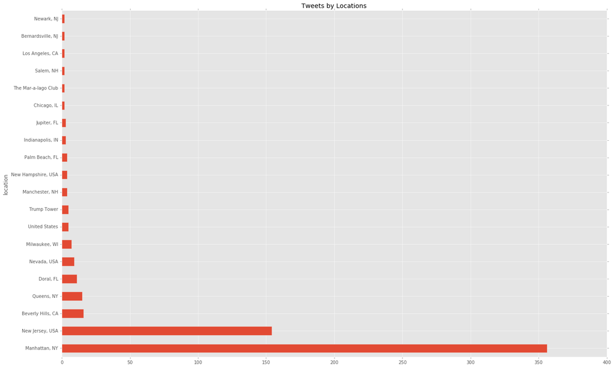

```python
location = location.set_index('location')
location[:20].plot(kind='barh', title='Tweets by Locations', legend=False, figsize=(22,14))
```

## Hashtags

```python
# # count

tags = []
for t in twits['tag']:
    if type(t) == str:
        tags.extend(t[1:-1].lower().split(', '))

tag = pd.DataFrame.from_dict(Counter(tags), orient = 'index').reset_index()
tag.columns = ['tag', 'count']
tag = tag.sort_values('count', ascending=False)
tag.reset_index(drop=True)[:20]
```

|  | tag | count |
| --- | --- | --- |
| 0 | trump2016 | 536 |
| 1 | makeamericagreatagain | 417 |
| 2 | votetrump | 65 |
| 3 | trump | 52 |
| 4 | gopdebate | 40 |
| 5 | demdebate | 35 |
| 6 | fitn | 29 |
| 7 | trumptrain | 26 |
| 8 | iacaucus | 21 |
| 9 | gop | 19 |
| 10 | teamtrump | 19 |
| 11 | snl | 18 |
| 12 | supertuesday | 18 |
| 13 | wiprimary | 13 |
| 14 | tcot | 12 |
| 15 | votetrump2016 | 11 |
| 16 | donaldtrump | 11 |
| 17 | trumpforpresident | 11 |
| 18 | potus | 11 |
| 19 | votetrumpsc | 10 |

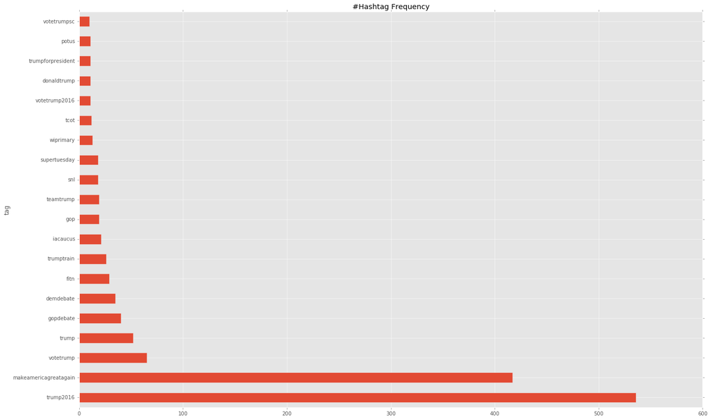

```python
tag = tag.set_index('tag')
tag[:20].plot(kind='barh', title='#Hashtag Frequency', legend=False, figsize=(22,14))
```

## @'s

```python
# @ count

ats = []
for a in twits['at']:
    if type(a) == str:
        ats.extend(a[1:-1].split(', '))

at = pd.DataFrame.from_dict(Counter(ats), orient='index').reset_index()
at.columns = ['at', 'count']
at = at.sort_values('count', ascending=False)
at = at.iloc[1:len(at['at']),:] # remove @realDonaldTrump
at.reset_index(drop=True)[:20]
```

|  | at | count |
| --- | --- | --- |
| 0 | FoxNews | 250 |
| 1 | CNN | 192 |
| 2 | megynkelly | 116 |
| 3 | JebBush | 76 |
| 4 | seanhannity | 72 |
| 5 | foxandfriends | 69 |
| 6 | oreillyfactor | 62 |
| 7 | Macys | 56 |
| 8 | nytimes | 48 |
| 9 | KarlRove | 44 |
| 10 | Morning_Joe | 42 |
| 11 | AnnCoulter | 35 |
| 12 | WSJ | 31 |
| 13 | ABC | 30 |
| 14 | greta | 30 |
| 15 | CNNPolitics | 29 |
| 16 | krauthammer | 28 |
| 17 | tedcruz | 28 |
| 18 | GOP | 27 |
| 19 | politico | 25 |

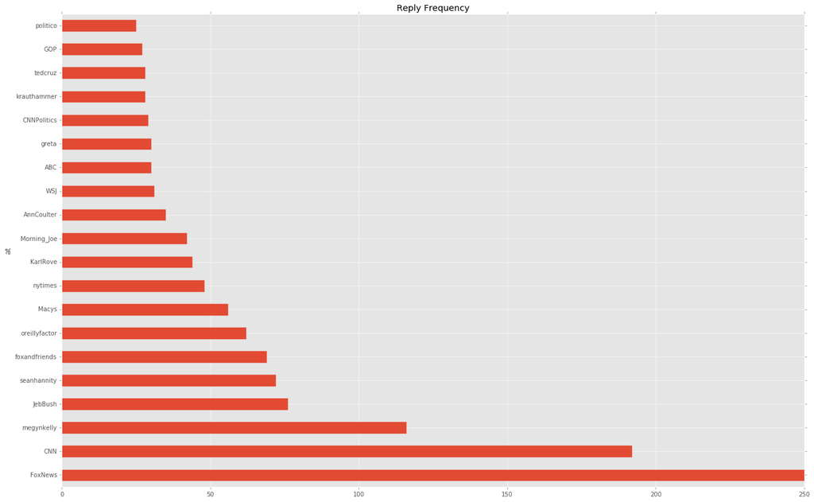

```python
at = at.set_index('at')
at[:20].plot(kind='barh', title='Reply Frequency', legend=False, figsize=(22,14))
```

## Words

```python
# word count
import nltk
from nltk.corpus import stopwords
#nltk.download("stopwords")
stops = stopwords.words('english')

words = []
for w in twits['twit']:
    words.extend(w.lower().split())
words = [x for x in words if '@' not in x]
words = [x for x in words if '#' not in x]
words = map(lambda x: re.sub('[^A-Za-z0-9]+', '', x), words)
words = [x for x in words if x not in str(stops)]

word = pd.DataFrame.from_dict(Counter(words), orient='index').reset_index()
word.columns = ['word', 'count']
word = word.sort_values('count', ascending=False)
word.reset_index(drop=True)[:30]
```

|  | word | count |
| --- | --- | --- |
| 0 | trump | 1169 |
| 1 | great | 912 |
| 2 | thank | 648 |
| 3 | america | 454 |
| 4 | donald | 373 |
| 5 | people | 364 |
| 6 | new | 326 |
| 7 | make | 318 |
| 8 | poll | 276 |
| 9 | like | 256 |
| 10 | president | 253 |
| 11 | get | 253 |
| 12 | hillary | 220 |
| 13 | cruz | 216 |
| 14 | vote | 215 |
| 15 | big | 214 |
| 16 | one | 205 |
| 17 | time | 201 |
| 18 | tonight | 175 |
| 19 | country | 171 |
| 20 | dont | 171 |
| 21 | debate | 168 |
| 22 | back | 165 |
| 23 | love | 162 |
| 24 | said | 161 |
| 25 | going | 158 |
| 26 | good | 157 |
| 27 | last | 156 |
| 28 | win | 150 |
| 29 | iowa | 149 |

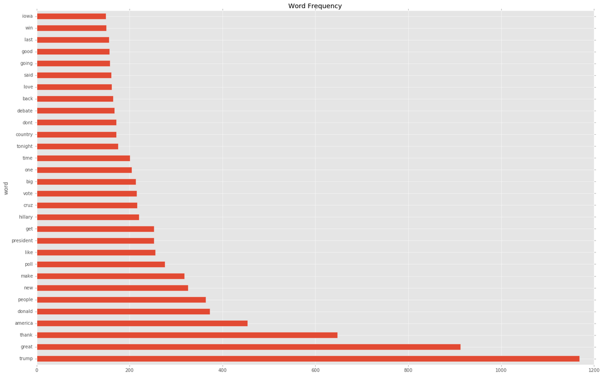

```python
word = word.set_index('word')
word[:30].plot(kind='barh', title='Word Frequency', legend=False, figsize=(22,14))
```

# Conclusion

- In about a year, Trump has grown the number of likes and retweets from under 50 to a couple thousand per tweet.
- Most of Trump's tweets with location are from Manhattan and New Jersey.
- Trump's 20 most frequent hashtags are political terms, with the exception of #SNL. #Trump2016 and #MakeAmericaGreatAgain are the top two.
- Trump tweets at media the most, with the exception of Jeb Bush who is is 4th favorite Twitter buddy.
- 'Trump' appears the most in the tweets, coming from articles and replies.
- Twitter does not play nice after loading around 10,000 tweets.

# Improvements

- Plot time series tweets to see progression over months
- Sentiment analysis of Trump's tweets
- Get #AskTrump tweets and find out what people think about Trump